# Assignment 1

2017-04-10

## Question 1: Inference for the binomial parameter:

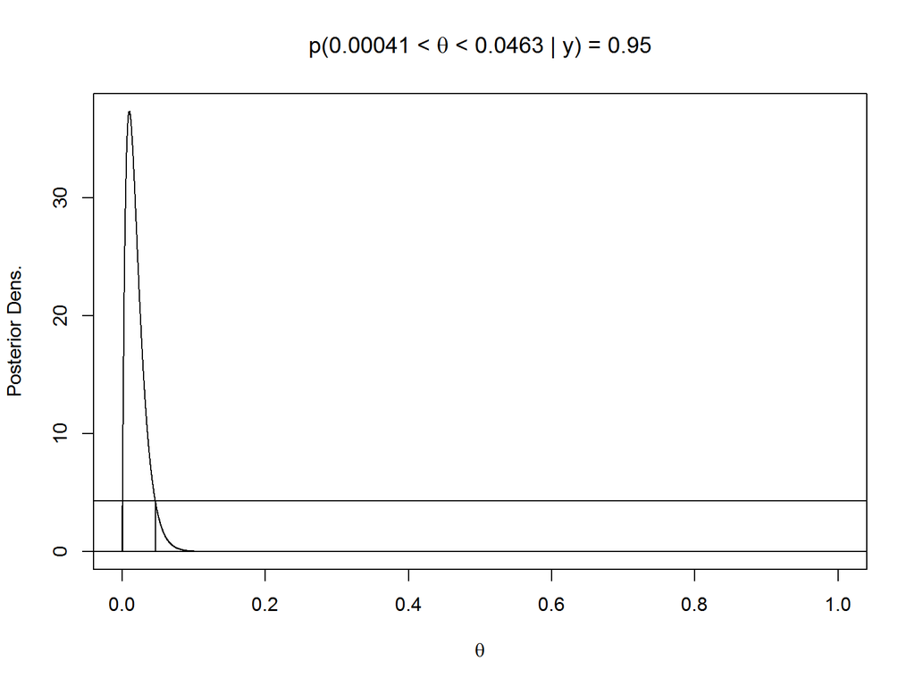

```r
solve.HPD.beta = function(shape1, shape2, credint = 0.95, plot=FALSE, ...){

  hpdfunc <- function(h, shape1, shape2){
    mode = (shape1 - 1)/(shape1 + shape2 - 2)
    lt = uniroot(f=function(x){ dbeta(x,shape1, shape2) - h},
                 lower=0, upper=mode)$root
    ut = uniroot(f=function(x){ dbeta(x,shape1, shape2) - h},
                 lower=mode, upper=1)$root
    coverage = pbeta(ut, shape1, shape2) - pbeta(lt, shape1, shape2)

    hpdval = abs(credint-coverage)

    results <<- data_frame("Lower"    = lt,
                           "Upper"    = ut,
                           "Coverage" = coverage,
                           "Height"   = h)
    return(hpdval)
  }

  # an upper limit for the hpdfunc optimiser.
  upper = max(dbeta(seq(0,1, by = 0.001), shape1, shape2))

    h = optimize(hpdfunc,
               interval = seq(0,upper,by = 0.001),
               lower = 0,
               tol = .Machine$double.eps,
               shape1,
               shape2)

  if (plot) {
    th = seq(0, 1, length=10000)
    plot(th, dbeta(th, shape1, shape2), t="l",
         xlab=expression(theta), ylab="Posterior Dens.") #Plot the curve
    abline(h=h) # plot the optimised 'height'
    segments(results[[2]],0,results[[2]],
             dbeta(results[[2]],shape1,shape2)) # the upper limit
    segments(results[[1]],0,results[[1]],
             dbeta(results[[1]],shape1,shape2)) # the lower limit
    title(bquote(paste("p(", .(round(results[[1]], 5))," < ", theta, " < ",
                       .(round(results[[2]],5)), " | " , y, ") = ",
                       .(round(results[[3]], 5))))) #title
  }
  return(results)}

y=1; n=100; a=1; b=1; p=0.95
df <- solve.HPD.beta(shape1 = y + a, shape2 = n - y + b, plot = TRUE)
```

2. Reproduce Agresti & Coull’s (1998) Figure 4 $(n = 10)$, and replicate for the Score and Bayes-Laplace & Jeffreys HPD intervals The code for generating the intervals in questions (b) - (e) is given below. The values for the sawtooth graphs are obtained by using vapply and a vector of values for the parameter between 0 and 1: e.g for the Wald we use “vapply(p,waldcover,0)”.

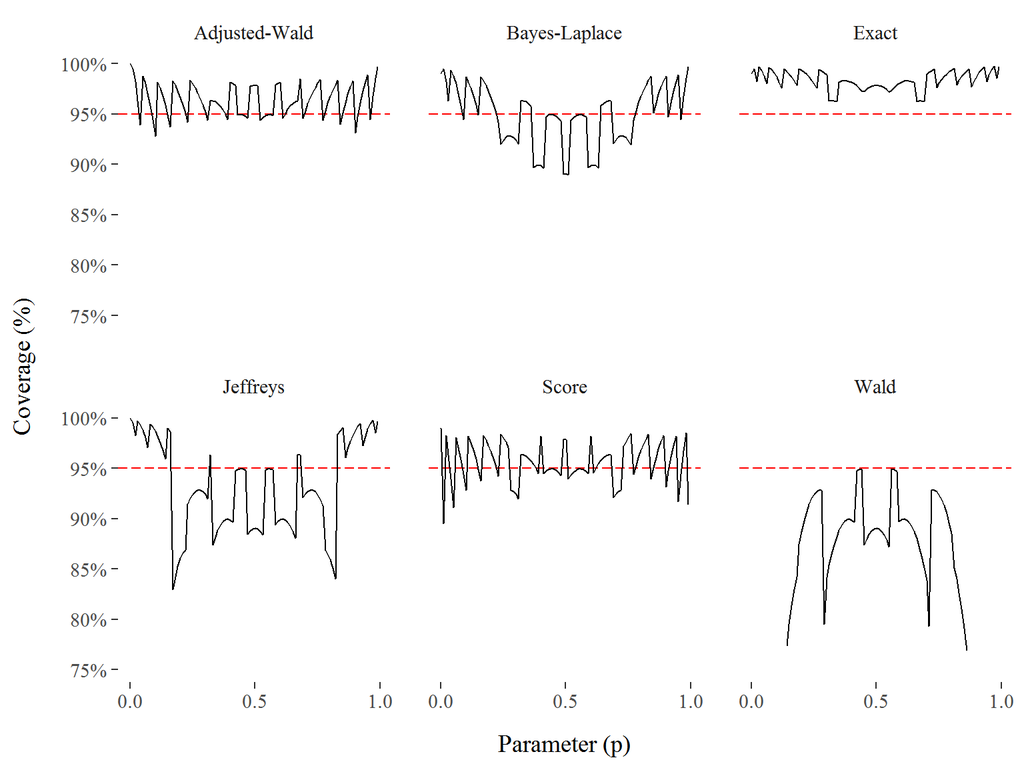

```r
n <- 10 # successes
a <- 0.05 # desired alpha
p <- seq(0.001,0.999,1/100) # vector of possible param. values.
z <- abs(qnorm(.5*a,0,1)) # z-score to use for some of the intervals.
source("Question1/1bData.R") # contains the code for generating the req.values: see appendix.
source("Question1/1bChart.R") # contains code for plotting the values.
q1bchart # calls the chart.
```

3. Repeat (b) for $n = 50$.

```r
n <- 50
a <- 0.05
p <- seq(0.001,0.999,1/100)
z <- abs(qnorm(.5*a,0,1))
source("Question1/1cData.R")
```

[figure not shown]

4. Compare the minimum coverage of the six graphs at (c)

| covinterval | mean(dens) | median(dens) | min(dens) |
| --- | --- | --- | --- |
| Adjusted-Wald | 0.9570598 | 0.9556680 | 0.9347150 |
| Bayes-Laplace | 0.9502425 | 0.9485846 | 0.9141887 |
| Exact | 0.9688356 | 0.9677209 | 0.9533931 |
| Jeffreys | 0.9407031 | 0.9411357 | 0.8503201 |
| Score | 0.9500408 | 0.9518466 | 0.8950698 |
| Wald | 0.8987441 | 0.9344978 | 0.0487941 |

5. The adjusted Wald interval appears to perform well with respect to frequentist coverage, if close to nominal combined with reasonable minimum coverage is aimed for. From a Bayesian point of view, performance of individual intervals is just as, if not more, important. Given $x = 0$, compare the adjusted Wald interval with the exact & Score intervals (all two-sided), and with the Bayes-Laplace & Jeffreys HPD intervals, for a range of values of $n$ and $\alpha$, comment on its limitations, and give an appropriate graphical illustration.

## Question 2: Inference for the Cauchy parameter:

1. Develop an R function to find percentiles of a (general) Cauchy posterior as discussed by Jaynes (1976, Example 6) and Box & Tiao (1973, p.64), to be used for the examples below.

```r
source("Question2/2a.R")
CauchyPercentage <- function(x, # a vector of samples
                             p, # a vector of possible parameters
                             y = NULL # a value to test Pr[p < y]
) {
  cauchydens <- function(x,p){

    cauchydist <- function(x,p) {
      H = vector(mode = "numeric",length = length(x))
      for(i in 1:length(x)){
        H[i] = (1+(x[i] - p)^2)^(-1)
      }
      return(prod(H))
    }
    dens = vapply(p,cauchydist,min(p), x = x)
    c = (integrate(dens, -Inf, Inf)$value)^(-1)
    data.frame(vparams = p, postdens = c*dens(p))
  }

  df = cauchydens(x,p)

  yind = ifelse(length(which(df$vparams == y))==1,
                which(df$vparams == y),
                max(which(df$vparams < y)))

  plot(df$vparams, df$postdens, type = 'l')
  abline(v = df$vparams[yind])
  abline(h = df[yind,"postdens"])

  cumdist = c*integrate(dens,-Inf,y)$value

  return((c(yind,df[yind,"postdens"],cumdist)))
}

CauchyHPD <- function(x, # vector of samples
                      p, # vector of possible parameter values
                      alpha = 0.95, # HPD interval value
                      tol = 0.0001) { # level of tolerance for exact HPD interval

  cauchydens <- function(x,p){

    cauchydist <- function(x,p) {
      H = vector(mode = "numeric",length = length(x))
      for(i in 1:length(x)){
        H[i] = (1+(x[i] - p)^2)^(-1)
      }
      return(prod(H))
    }
    dens = function(p) vapply(p,cauchydist,min(p), x = x)
    c = (integrate(dens, -Inf, Inf)$value)^(-1)
    data.frame(vparams = p, postdens = c*dens(p))
  }

  df = cauchydens(x,p)

  cumdist = cumsum(df$postdens)*diff(df$vparams)[1]
  post_median = which.min(abs(cumdist-0.5))

  HPDlimits <- function(post_dens) { ## find lower and upper values for which
    ## prob dens is closest to target value
    lower = which.min(abs(df$postdens[1:post_median]-post_dens))
    upper = which.min(abs(df$postdens[(post_median+1):length(df$postdens)]-post_dens))+post_median
    limits = c(lower,upper)
  }

  HPDlimitarea <- function(post_dens) {
    limitints = HPDlimits(post_dens)
    limitarea = sum(df$postdens[limitints[1]:limitints[2]])*diff(df$vparams)[1]
  }
  ## find credible interval
  v2 = seq(0,max(df$postdens),by=tol)
  vals = sapply(v2,HPDlimitarea)
  w = which.min(abs(vals-alpha))
  r = c(df$vparams[HPDlimits(v2[w])])
  names(r) = c("lower","upper")
  par(mfrow = c(1,2))
  plot(df$vparams, cumdist, type = 'l')
  abline(h = 0.5)
  abline(v = df$vparams[post_median], col = 'red')
  abline(v = r["upper"], col = 'blue')
  abline(v = r["lower"], col = 'blue')
  plot(df$vparams, df$postdens, type = 'l')
  abline(v = df$vparams[post_median], col = 'red')
  abline(h = df[HPDlimits(v2[w])[1],"postdens"])
  abline(v = r["upper"], col = 'blue')
  abline(v = r["lower"], col = 'blue')
  return(r)
}
```

2. Consider Jaynes’ example of $n = 2$ observations $(3, 5)$: plot the posterior and calculate the 90% central credible interval. Explain why it is quite different from the confidence interval derived by Jaynes (p.202).

```r
source("Question2/2b.R")
```

3. Consider Box & Tiao’s example of $n = 5$ observations $(11.4, 7.3, 9.8, 13.7, 10.6)$: plot the posterior and calculate 95% central and HPD credible intervals and check $Pr[\theta < 11.5]$ given by Box & Tiao.

```r
source("Question2/2c.R")
```

4. Consider Berger’s (1985, p.141) example of $n = 5$ observations $(4.0, 5.5, 7.5, 4.5, 3.0)$: calculate 95% central and HPD credible intervals, with and without Berger’s restriction $(\theta > 0)$.

```r
source("Question2/2d.R")
```

5. Clearly, Berger’s restriction $(\theta > 0)$ will sometimes lead to a posterior quite different from the unrestricted posterior. Plot this restricted posterior for the hypothetical negative version of Berger’s example: i.e. $(-4.0, -5.5, -7.5, -4.5, -3.0)$, and calculate the 95% HPD interval.

```r
source("Question2/2e.R")
```